# 心臟病發作風險預測：決策樹優化分析 (R Language)

## 資料

- 資料名:心臟病分類資料集 (A dataset for heart attack classification)
- 資料來源:https://www.kaggle.com/rashikrahmanpritom/heart-attack-analysis-prediction-dataset

## 目標

- 以變數(年齡 性別 胸痛類型 血壓…等)建立決策樹模型，預測心臟病發作的機會減少或增加

## 資料處理與類別轉換

在此步驟中，將類別型變數從原始的數值編碼（0, 1…）轉換為具備語意標籤的 **Factor（因子）** 型態。

**點擊展開：變數類別轉換與資料清理程式碼**

```r
# 進行欄位篩選與 Factor 轉換
cheart <- heart %>%
  select(-c(slp, thall)) %>%
  mutate(
    sex     = factor(sex, levels = c(0, 1), labels = c('female', 'male')),
    cp      = factor(cp, levels = c(0, 1, 2, 3), labels = c('typical', 'atypical', 'non-anginal', 'asymptomatic')),
    exng    = factor(exng, levels = c(0, 1), labels = c('No', 'YES')),
    restecg = factor(restecg, levels = c(0, 1, 2), labels = c('normal', 'ST-T wave abnormality', 'left ventricular hypertrophy')),
    fbs     = factor(fbs, levels = c(0, 1), labels = c(FALSE, TRUE)),
    output  = factor(output, levels = c(0, 1), labels = c('less', 'more'))
  )

# 檢查清理後的資料結構
skim(cheart)
```

Data summary

| Name | cheart |
| --- | --- |
| Number of rows | 303 |
| Number of columns | 12 |
| _______________________ |  |
| Column type frequency: |  |
| factor | 6 |
| numeric | 6 |
| ________________________ |  |
| Group variables | None |

**Variable type: factor**

| skim_variable | n_missing | complete_rate | ordered | n_unique | top_counts |
| --- | --- | --- | --- | --- | --- |
| sex | 0 | 1 | FALSE | 2 | mal: 207, fem: 96 |
| cp | 0 | 1 | FALSE | 4 | typ: 143, non: 87, aty: 50, asy: 23 |
| fbs | 0 | 1 | FALSE | 2 | FAL: 258, TRU: 45 |
| restecg | 0 | 1 | FALSE | 3 | ST-: 152, nor: 147, lef: 4 |
| exng | 0 | 1 | FALSE | 2 | No: 204, YES: 99 |
| output | 0 | 1 | FALSE | 2 | mor: 165, les: 138 |

**Variable type: numeric**

| skim_variable | n_missing | complete_rate | mean | sd | p0 | p25 | p50 | p75 | p100 | hist |
| --- | --- | --- | --- | --- | --- | --- | --- | --- | --- | --- |
| age | 0 | 1 | 54.37 | 9.08 | 29 | 47.5 | 55.0 | 61.0 | 77.0 | ▁▆▇▇▁ |
| trtbps | 0 | 1 | 131.62 | 17.54 | 94 | 120.0 | 130.0 | 140.0 | 200.0 | ▃▇▅▁▁ |
| chol | 0 | 1 | 246.26 | 51.83 | 126 | 211.0 | 240.0 | 274.5 | 564.0 | ▃▇▂▁▁ |
| thalachh | 0 | 1 | 149.65 | 22.91 | 71 | 133.5 | 153.0 | 166.0 | 202.0 | ▁▂▅▇▂ |
| oldpeak | 0 | 1 | 1.04 | 1.16 | 0 | 0.0 | 0.8 | 1.6 | 6.2 | ▇▂▁▁▁ |
| caa | 0 | 1 | 0.73 | 1.02 | 0 | 0.0 | 0.0 | 1.0 | 4.0 | ▇▃▂▁▁ |

## 數據拆分與預處理 (Data Splitting)

為了建立並評估模型，我們將清理後的資料以 **80/20** 的比例拆分為訓練集與測試集。

**點擊展開資料拆分程式碼**

```r
# 依目標變數 output 分層抽樣，確保比例一致
input_m <- cheart[which(cheart$output == 'more'),]
input_l <- cheart[which(cheart$output == 'less'),]

set.seed(100) # 設定隨機種子以利實驗重現
input_m_training <- sample(1:nrow(input_m), 0.8 * nrow(input_m))
input_l_training <- sample(1:nrow(input_l), 0.8 * nrow(input_l))

# 合成訓練集與測試集
traindata <- rbind(input_m[input_m_training,], input_l[input_l_training,])
testdata  <- rbind(input_m[-input_m_training,], input_l[-input_l_training,])
```

**拆分結果摘要**

確認了拆分後的樣本數與目標變數 `output` 的分布情況，確保模型不會因為資料偏移而產生偏誤。

[output not shown]

訓練集與測試集之樣本分布對照表 :::

## 建立決策樹模型 (Classification Tree)

首先使用 rpart 套件建立基礎的分類決策樹，並透過視覺化圖表觀察模型如何根據臨床特徵進行分類。

**使用 rpart 建立模型**

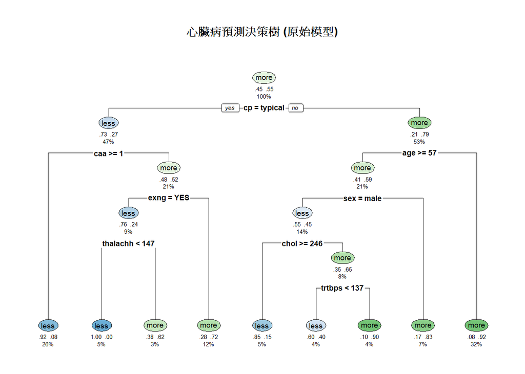

```r
# 訓練模型
fit <- rpart(output ~ ., data = traindata, method = 'class')

# 視覺化決策樹
rpart.plot(fit, main = "心臟病預測決策樹 (原始模型)",
           type = 2, extra = 104, under = TRUE, faclen = 0)
```

**Note如何閱讀此圖表？**

- **頂層節點 (Root Node)**：第一個分割變數為 `cp`（胸痛類型），代表預測力最強。
- **節點內數值**：
  1. 第一行 (`more`/`less`)：該節點的預測結果。
  2. 第二行 (如 `0.45 0.55`)：分別代表 `less` 或 `more` 的機率。
  3. 第三行 (如 `100%`)：該節點覆蓋的樣本佔比。
- **顏色分類**：**綠色**代表高風險 (`more`)，**藍色**代表低風險 (`less`)。顏色越深表示該分類的信心度（純度）越高。

**模型效能評估與剪枝 (Pruning)**

**模型剪枝與 CP 值分析**

```r
# 顯示 CP 表與視覺化
printcp(fit)
```

```
Classification tree:
rpart(formula = output ~ ., data = traindata, method = "class")

Variables actually used in tree construction:
[1] age      caa      chol     cp       exng     sex      thalachh trtbps

Root node error: 110/242 = 0.45455

n= 242

        CP nsplit rel error  xerror     xstd
1 0.472727      0   1.00000 1.00000 0.070418
2 0.059091      1   0.52727 0.52727 0.060370
3 0.027273      3   0.40909 0.48182 0.058488
4 0.018182      6   0.32727 0.50000 0.059265
5 0.010000      8   0.29091 0.45455 0.057258
```

**模型剪枝與 CP 值分析**

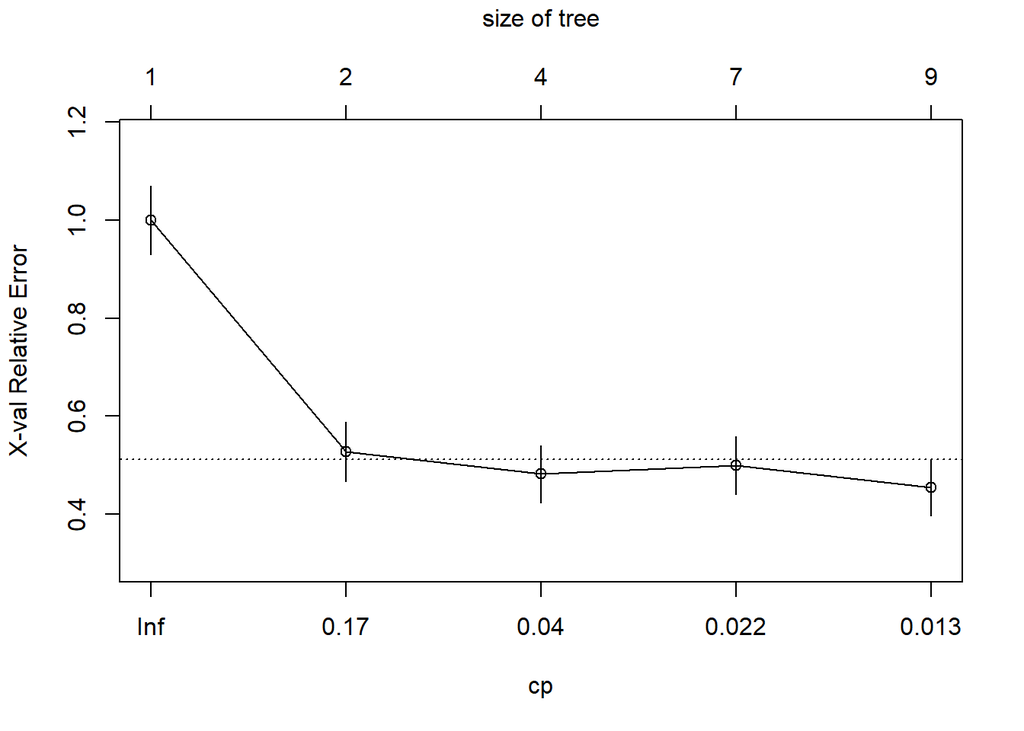

```r
plotcp(fit)
```

**模型剪枝與 CP 值分析**

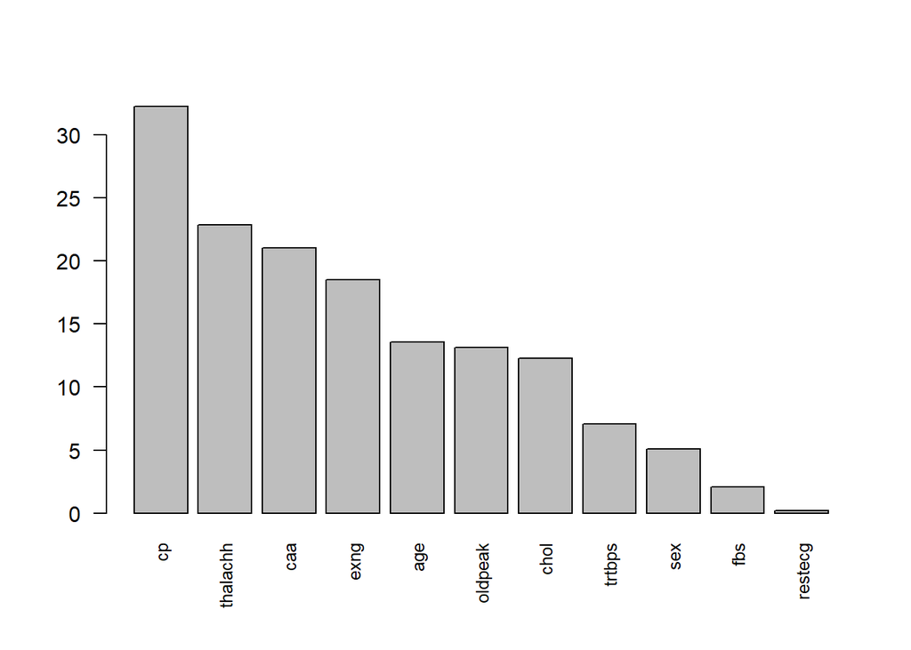

```r
barplot(fit$variable.importance, las = 2, cex.names = 0.8)
```

**模型剪枝與 CP 值分析**

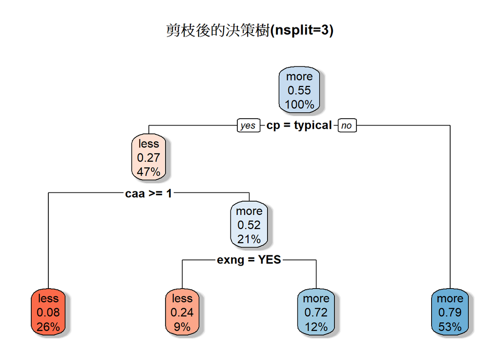

```r
# 設定 CP 為 0.027273 (對應 nsplit=3)
fit.prune<- prune(fit, cp = 0.027273)

# 繪製剪枝後的樹
rpart.plot(fit.prune, main = "剪枝後的決策樹(nsplit=3)",
           box.palette = "RdBu", shadow.col = "gray")
```

**Note如何閱讀此圖表？**

- 解讀方式與心臟病預測決策樹 (原始模型)相同。
- **顏色分類**：**藍色**代表高風險 (`more`)，**橘色**代表低風險 (`less`)。顏色越深表示該分類的信心度（純度）越高。
- 觀察剪枝後的圖表，我們可以發現模型捨棄了如 chol (膽固醇) 或 trtbps (血壓) 等細微的分支，轉而聚焦在最具影響力的核心變數：**cp (胸痛類型)、caa (血管數量)、 exng(運動誘導心絞痛)**，雖然 thalachh 重要性排第二，但在「剪枝」時，演算法更看重的是路徑的純度與結構的簡潔。

```r
# 使用 CP=0.027 的剪枝模型進行預測
predict_prune <- predict(fit.prune, newdata = testdata, type = 'class')

# 建立混淆矩陣
tbl_prune <- table(Predicted = predict_prune, Actual = testdata$output)

# 計算最終準確率
accuracy_prune <- sum(diag(tbl_prune)) / sum(tbl_prune)
```

**Tip準確率結果**

決策樹在測試集上的準確率為：**82%**。

## 模型驗證：K-Fold 交叉驗證

為了確認上述剪枝策略並非特定資料分佈下的偶然結果，我們進一步執行 K-fold 驗證。

使用 caret 套件進行 5-fold 交叉驗證，以確保模型的穩定性與概括能力。由於本訓練集的樣本數為242，使用5-fold，每個驗證組有大約50筆資料。若使用k=10估計會最準確（低偏差），因為每次訓練都用了 90%的資料，最接近原始模型，但因為每個驗證組僅24筆資料，若剛好都抽取到極端值有可能造成變異較高。

**5-fold 交叉驗證**

```r
# 設定 5-fold 交叉驗證參數
train_c <- trainControl(method = 'cv', number = 5)

# 訓練模型
train_cmodel <- train(output ~ ., data = traindata,
                      method = 'rpart',
                      trControl = train_c,
                      na.action = na.pass)
train_cmodel
```

```
CART

242 samples
 11 predictor
  2 classes: 'less', 'more'

No pre-processing
Resampling: Cross-Validated (5 fold)
Summary of sample sizes: 193, 193, 194, 194, 194
Resampling results across tuning parameters:

  cp          Accuracy   Kappa
  0.05454545  0.7272109  0.4497399
  0.06363636  0.7190476  0.4311060
  0.42727273  0.6033163  0.1496979

Accuracy was used to select the optimal model using the largest value.
The final value used for the model was cp = 0.05454545.
```

**NoteK-Fold準確率結果**

因此本專案最終捨棄系統自動建議的 CP = 0.054，改採 **CP = 0.027**。